# Module 48

#### Hemi-module gene counts:

232 probesets in hemi-module A.  
57 probesets in hemi-module B.  
Note: While the mapping of probesets to genes is usually one-to-one, some genes are targeted by multiple probesets, some probesets target multiple genes, and some probesets do not target any genes (i.e., the region of the genome they match is no longer considered genic).

#### Contrast SVE:

Signed variance explained (SVE) provides an indication of how similar a set of fold changes are to a gene module’s weight vector. An SVE value of 0.3, for example, indicates that 30% of the variance explained by the entire module set is accounted for by the module in question. Shown here are the SVE values for this module across a compendium of fold changes (contrasts). Extreme SVE values (e.g., > 0.05) indicate that those contrasts specifically induce (orange dots) or specifically repress (blue dots) this module. Examining the experimental conditions being compared in such contrasts (see tables below the figure) may provide insight into the gene module’s function.

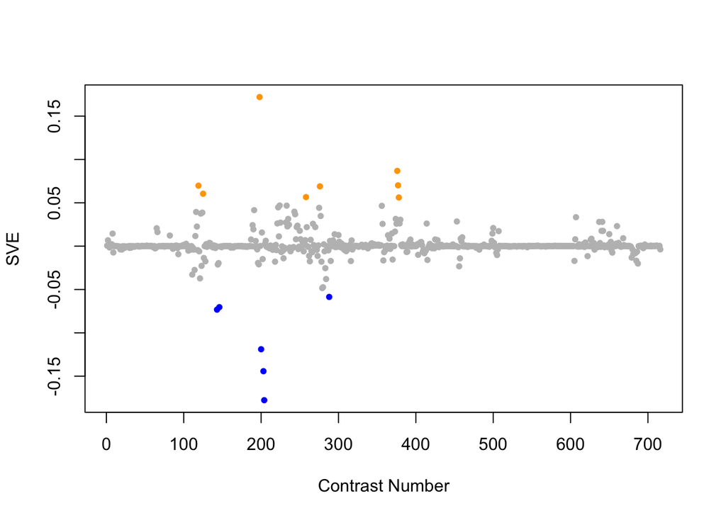

Positive SVE Contrasts:

|  | Contrast.Num | SVE | GEO.GSE | Cond.1 | Cond.2 | Mutation |
| --- | --- | --- | --- | --- | --- | --- |
| GSE43959.s3t2.vs.s4t2 | 198 | 0.17 | GSE43959 | N2 gravid adult on Comamonas DA1877 rep 1 | N2 gravid adult on 1:1000 Comamonas DA1877 rep 1 |  |
| GSE35354B.s1t2.vs.s1t1 | 376 | 0.09 | GSE35354 | TA100_rep1 | TA Control_rep1 |  |
| GSE35354B.s1t3.vs.s1t1 | 377 | 0.07 | GSE35354 | TA200_rep1 | TA Control_rep1 |  |
| GSE54024.s1t1.vs.s6t1 | 119 | 0.07 | GSE54024 | Wild type young adults, biological rep 1 | isp-1(qm150) ced-4(n1162) double mutant young adults, biological rep 1 | isp-1;ced-4 |
| GSE41366B.s1t2.vs.s0t2 | 276 | 0.07 | GSE41366 | low_DDVP-8h_expose-20h_harvest-rep1 | control-8h_expose-20h_harvest-rep1 |  |
| GSE54024.s1t1.vs.s2t1 | 125 | 0.06 | GSE54024 | Wild type young adults, biological rep 1 | Wild type young adults treated with 0.1mM paraquat, biological rep 1 |  |
| GSE41366A.s2t3.vs.s0t3 | 258 | 0.06 | GSE41366 | high_DDVP-2h_expose-20h_harvest-rep1 | control-2h_expose-20h_harvest-rep1 |  |
| GSE35354B.s1t4.vs.s1t1 | 378 | 0.06 | GSE35354 | TA300_rep1 | TA Control_rep1 |  |

Negative SVE Contrasts:

|  | Contrast.Num | SVE | GEO.GSE | Cond.1 | Cond.2 | Mutation |
| --- | --- | --- | --- | --- | --- | --- |
| GSE43952.s2t1.vs.s0t1 | 204 | -0.18 | GSE43952 | pcca-1(ok2282) fed Comamonas DA1877 rep1 | N2 gravid adult fed Comamonas DA1877 rep 1 | pcca-1 |
| GSE43952.s1t1.vs.s0t1 | 203 | -0.14 | GSE43952 | metr-1(ok521) fed Comamonas DA1877 rep 1 | N2 gravid adult fed Comamonas DA1877 rep 1 | metr-1 |
| GSE43959.s1t2.vs.s3t2 | 200 | -0.12 | GSE43959 | N2 gravid adult on E. coli OP50 rep 1 | N2 gravid adult on Comamonas DA1877 rep 1 |  |
| GSE50513.s3t1.vs.s1t1 | 143 | -0.07 | GSE50513 | zip-2 OP50 - rep 1 | L4440 OP50 - rep 1 | zip-2 |
| GSE50513.s4t1.vs.s2t1 | 146 | -0.07 | GSE50513 | zip-2 PA14 - rep 1 | L4440 PA14 - rep 1 | zip-2 |
| GSE41366C.s1t4.vs.s0t4 | 288 | -0.06 | GSE41366 | low_DDVP-continuous_expose-20h_harvest-rep1 | control-continuous_expose-14h_harvest-rep1 |  |

$~$

#### Contrast SVE, Up-Regulated Genes Only:

Calculating SVE for up-regulated and down-regulated genes separately may be more informative in many cases than projecting the up- and down- gene sets together. This is due to the fact that the weight distribution of many modules is highly skewed, indicating that only one of the hemi-modules may be biologically meaningful (i.e., a set of genes are strongly correlated by only a few genes (or none) are strongly anti-correlated to that set.)

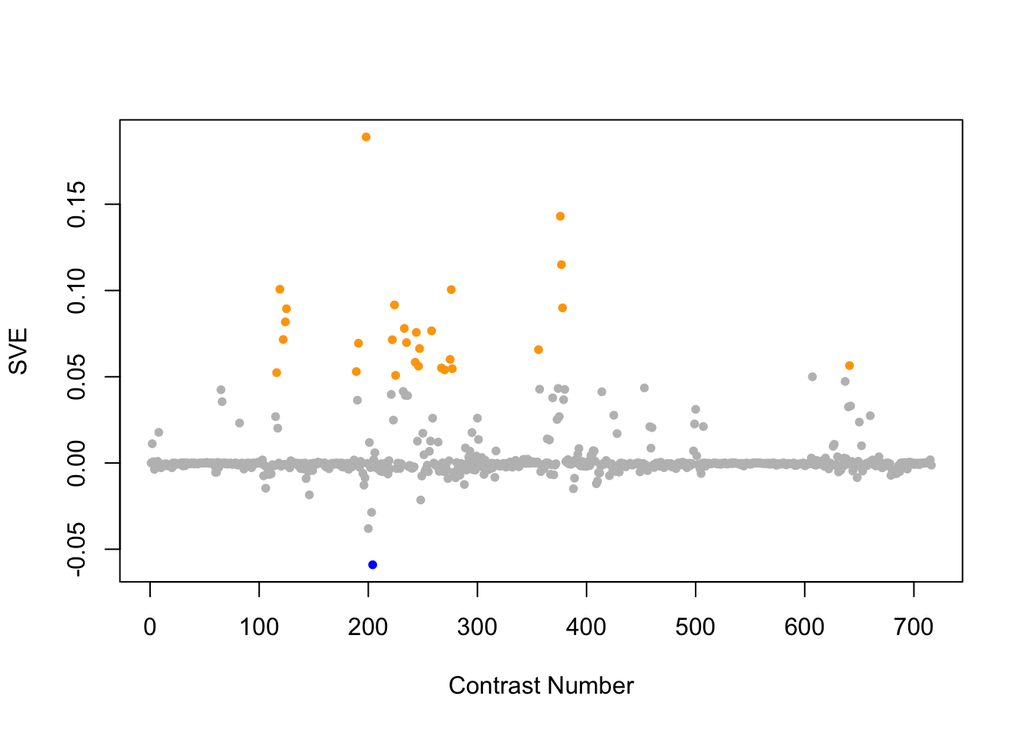

Positive SVE Contrasts:

|  | Contrast.Num | SVE | GEO.GSE | Cond.1 | Cond.2 | Mutation |
| --- | --- | --- | --- | --- | --- | --- |
| GSE43959.s3t2.vs.s4t2 | 198 | 0.19 | GSE43959 | N2 gravid adult on Comamonas DA1877 rep 1 | N2 gravid adult on 1:1000 Comamonas DA1877 rep 1 |  |
| GSE35354B.s1t2.vs.s1t1 | 376 | 0.14 | GSE35354 | TA100_rep1 | TA Control_rep1 |  |
| GSE35354B.s1t3.vs.s1t1 | 377 | 0.11 | GSE35354 | TA200_rep1 | TA Control_rep1 |  |
| GSE54024.s1t1.vs.s6t1 | 119 | 0.10 | GSE54024 | Wild type young adults, biological rep 1 | isp-1(qm150) ced-4(n1162) double mutant young adults, biological rep 1 | isp-1;ced-4 |
| GSE41366B.s1t2.vs.s0t2 | 276 | 0.10 | GSE41366 | low_DDVP-8h_expose-20h_harvest-rep1 | control-8h_expose-20h_harvest-rep1 |  |
| GSE42592A.s1t3.vs.s1t2 | 224 | 0.09 | GSE42592 | acrylamide_low_expose-8h_rep1 | acrylamide_low_expose-4h_rep1 |  |
| GSE35354B.s1t4.vs.s1t1 | 378 | 0.09 | GSE35354 | TA300_rep1 | TA Control_rep1 |  |
| GSE54024.s1t1.vs.s2t1 | 125 | 0.09 | GSE54024 | Wild type young adults, biological rep 1 | Wild type young adults treated with 0.1mM paraquat, biological rep 1 |  |
| GSE54024.s1t1.vs.s3t1 | 124 | 0.08 | GSE54024 | Wild type young adults, biological rep 1 | nuo-6(qm200) young adults, biological rep 1 | nuo-6 |
| GSE42592B.s0t3.vs.s0t1 | 233 | 0.08 | GSE42592 | cadmium_control_expose-8h_rep1 | cadmium_control_expose-0h_rep1 |  |
| GSE41366A.s2t3.vs.s0t3 | 258 | 0.08 | GSE41366 | high_DDVP-2h_expose-20h_harvest-rep1 | control-2h_expose-20h_harvest-rep1 |  |
| GSE42592C.s0t3.vs.s0t1 | 244 | 0.08 | GSE42592 | mercury_control_expose-8h_rep1 | mercury_control_expose-0h_rep1 |  |
| GSE54024.s1t1.vs.s4t1 | 122 | 0.07 | GSE54024 | Wild type young adults, biological rep 1 | isp-1(qm150) young adults, biological rep 1 | isp-1 |
| GSE42592A.s0t3.vs.s0t1 | 222 | 0.07 | GSE42592 | acrylamide_control_expose-8h_rep1 | acrylamide_control_expose-0h_rep1 |  |
| GSE42592B.s1t3.vs.s1t2 | 235 | 0.07 | GSE42592 | cadmium_low_expose-8h_rep1 | cadmium_low_expose-4h_rep1 |  |
| GSE46291.s2t2.vs.s2t1 | 191 | 0.07 | GSE46291 | L4-lethargus_rep1 | L3-lethargus_rep1 |  |
| GSE42592C.s2t3.vs.s2t2 | 247 | 0.07 | GSE42592 | mercury_mid_expose-8h_rep1 | mercury_mid_expose-4h_rep1 |  |
| GSE38196.s1t1.vs.s0t1 | 356 | 0.07 | GSE38196 | atfs-1(tm4525)-control, biological rep1 | wild-type-control, biological rep1 | afts-1 |
| GSE41366B.s2t2.vs.s0t2 | 275 | 0.06 | GSE41366 | high_DDVP-8h_expose-20h_harvest-rep1 | control-8h_expose-20h_harvest-rep1 |  |
| GSE42592C.s0t2.vs.s0t1 | 243 | 0.06 | GSE42592 | mercury_control_expose-4h_rep1 | mercury_control_expose-0h_rep1 |  |
| GSE18132.s1t2.vs.s1t1 | 641 | 0.06 | GSE18132 | Ogt Fed L4, biological replicate 1 | Ogt starved L1, biological replicate 1 |  |
| GSE42592C.s1t3.vs.s1t2 | 246 | 0.06 | GSE42592 | mercury_low_expose-8h_rep1 | mercury_low_expose-4h_rep1 |  |
| GSE41366A.s2t2.vs.s2t1 | 267 | 0.06 | GSE41366 | high_DDVP-2h_expose-14h_harvest-rep1 | high_DDVP-2h_expose-8h_harvest-rep1 |  |
| GSE41366B.s2t3.vs.s0t3 | 277 | 0.05 | GSE41366 | high_DDVP-8h_expose-26h_harvest-rep1 | control-8h_expose-26h_harvest-rep1 |  |
| GSE41366A.s1t2.vs.s1t1 | 270 | 0.05 | GSE41366 | low_DDVP-2h_expose-14h_harvest-rep1 | low_DDVP-2h_expose-8h_harvest-rep1 |  |
| GSE46291.s1t3.vs.s1t1 | 189 | 0.05 | GSE46291 | Adult_rep1 | L3_rep1 |  |
| GSE54024.s4t1.vs.s6t1 | 116 | 0.05 | GSE54024 | isp-1(qm150) young adults, biological rep 1 | isp-1(qm150) ced-4(n1162) double mutant young adults, biological rep 1 | ced-4 |
| GSE42592A.s2t3.vs.s2t2 | 225 | 0.05 | GSE42592 | acrylamide_mid_expose-8h_rep1 | acrylamide_mid_expose-4h_rep1 |  |

Negative SVE Contrasts:

|  | Contrast.Num | SVE | GEO.GSE | Cond.1 | Cond.2 | Mutation |
| --- | --- | --- | --- | --- | --- | --- |
| GSE43952.s2t1.vs.s0t1 | 204 | -0.06 | GSE43952 | pcca-1(ok2282) fed Comamonas DA1877 rep1 | N2 gravid adult fed Comamonas DA1877 rep 1 | pcca-1 |
| GSE43959.s1t2.vs.s3t2 | 200 | -0.04 | GSE43959 | N2 gravid adult on E. coli OP50 rep 1 | N2 gravid adult on Comamonas DA1877 rep 1 |  |
| GSE43952.s1t1.vs.s0t1 | 203 | -0.03 | GSE43952 | metr-1(ok521) fed Comamonas DA1877 rep 1 | N2 gravid adult fed Comamonas DA1877 rep 1 | metr-1 |
| GSE42192.s1t2.vs.s0t2 | 248 | -0.02 | GSE42192 | C.elegans fed with CNCM I-3690 10 days rep1 | C.elegans fed with E.coli OP50 10 days rep1 |  |
| GSE50513.s4t1.vs.s2t1 | 146 | -0.02 | GSE50513 | zip-2 PA14 - rep 1 | L4440 PA14 - rep 1 | zip-2 |

$~$

#### Contrast SVE, Down-Regulated Genes Only:

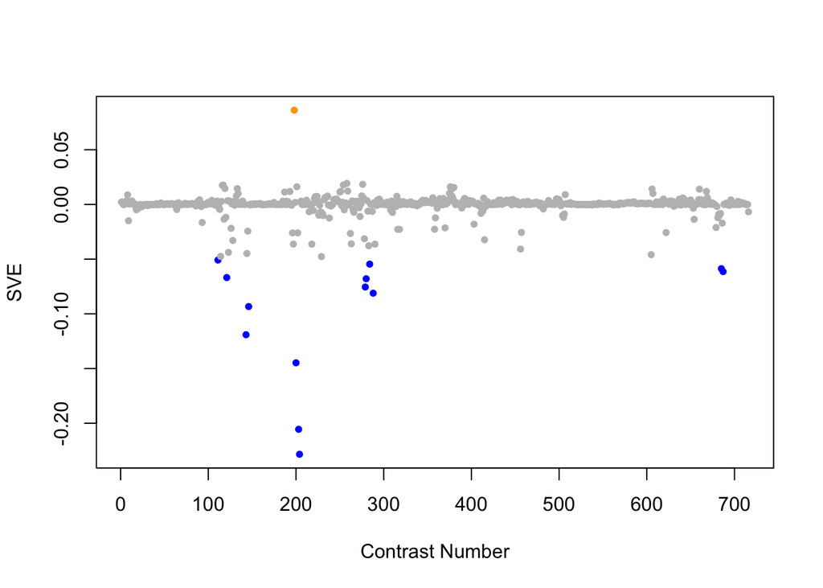

Positive SVE Contrasts:

|  | Contrast.Num | SVE | GEO.GSE | Cond.1 | Cond.2 | Mutation |
| --- | --- | --- | --- | --- | --- | --- |
| GSE43959.s3t2.vs.s4t2 | 198 | 0.09 | GSE43959 | N2 gravid adult on Comamonas DA1877 rep 1 | N2 gravid adult on 1:1000 Comamonas DA1877 rep 1 |  |
| GSE41366A.s2t3.vs.s0t3 | 258 | 0.02 | GSE41366 | high_DDVP-2h_expose-20h_harvest-rep1 | control-2h_expose-20h_harvest-rep1 |  |
| GSE41366B.s1t2.vs.s0t2 | 276 | 0.02 | GSE41366 | low_DDVP-8h_expose-20h_harvest-rep1 | control-8h_expose-20h_harvest-rep1 |  |
| GSE42192.s0t2.vs.s0t1 | 254 | 0.02 | GSE42192 | C.elegans fed with E.coli OP50 10 days rep1 | C.elegans fed with E.coli OP50 3 days rep1 |  |
| GSE54024.s3t1.vs.s6t1 | 117 | 0.02 | GSE54024 | nuo-6(qm200) young adults, biological rep 1 | isp-1(qm150) ced-4(n1162) double mutant young adults, biological rep 1 |  |

Negative SVE Contrasts:

|  | Contrast.Num | SVE | GEO.GSE | Cond.1 | Cond.2 | Mutation |
| --- | --- | --- | --- | --- | --- | --- |
| GSE43952.s2t1.vs.s0t1 | 204 | -0.23 | GSE43952 | pcca-1(ok2282) fed Comamonas DA1877 rep1 | N2 gravid adult fed Comamonas DA1877 rep 1 | pcca-1 |
| GSE43952.s1t1.vs.s0t1 | 203 | -0.21 | GSE43952 | metr-1(ok521) fed Comamonas DA1877 rep 1 | N2 gravid adult fed Comamonas DA1877 rep 1 | metr-1 |
| GSE43959.s1t2.vs.s3t2 | 200 | -0.14 | GSE43959 | N2 gravid adult on E. coli OP50 rep 1 | N2 gravid adult on Comamonas DA1877 rep 1 |  |
| GSE50513.s3t1.vs.s1t1 | 143 | -0.12 | GSE50513 | zip-2 OP50 - rep 1 | L4440 OP50 - rep 1 | zip-2 |
| GSE50513.s4t1.vs.s2t1 | 146 | -0.09 | GSE50513 | zip-2 PA14 - rep 1 | L4440 PA14 - rep 1 | zip-2 |
| GSE41366C.s1t4.vs.s0t4 | 288 | -0.08 | GSE41366 | low_DDVP-continuous_expose-20h_harvest-rep1 | control-continuous_expose-14h_harvest-rep1 |  |
| GSE41366B.s0t2.vs.s0t1 | 279 | -0.08 | GSE41366 | control-8h_expose-20h_harvest-rep1 | control-8h_expose-14h_harvest-rep1 |  |
| GSE41366B.s0t3.vs.s0t1 | 280 | -0.07 | GSE41366 | control-8h_expose-26h_harvest-rep1 | control-8h_expose-14h_harvest-rep1 |  |
| GSE54024.s2t1.vs.s4t1 | 121 | -0.07 | GSE54024 | Wild type young adults treated with 0.1mM paraquat, biological rep 1 | isp-1(qm150) young adults, biological rep 1 |  |
| GSE12298C.s2t1.vs.s0t1 | 687 | -0.06 | GSE12298 | mefloquine_mid_dose-rep1 | mefloquine_control-rep1 |  |
| GSE12298C.s3t1.vs.s0t1 | 685 | -0.06 | GSE12298 | mefloquine_high_dose-rep1 | mefloquine_control-rep1 |  |
| GSE41366B.s1t3.vs.s1t1 | 284 | -0.05 | GSE41366 | low_DDVP-8h_expose-26h_harvest-rep1 | low_DDVP-8h_expose-14h_harvest-rep1 |  |
| GSE54024.s6t1.vs.s5t1 | 111 | -0.05 | GSE54024 | isp-1(qm150) ced-4(n1162) double mutant young adults, biological rep 1 | ced-4(n1162) young adults, biological rep 1 | isp-1 |

$~$

$~$

#### GO Term Enrichment:

This analysis tests each hemi-module for enrichment of specific GO terms. Only gene-level annotations (e.g., as would be found on the gene’s page in Wormbase) are tested - the hierarchical structure of the GO ontology is not taken into account.

*Note: At least the top two most enriched terms from each GO domain (BP/MF/CC) are shown, even when not statistically significant.*

##### Enriched GO terms: Hemi-module A

| ID | GO.Term | GO Domain | Raw p-value | Adj p-value |
| --- | --- | --- | --- | --- |
| [GO_0006470](http://amigo.geneontology.org/amigo/term/GO:0006470) | protein dephosphorylation | BP | 1.24e-08 | 4.51e-05 |
| [GO_0035335](http://amigo.geneontology.org/amigo/term/GO:0035335) | peptidyl-tyrosine dephosphorylation | BP | 1.53e-05 | 2.57e-02 |
| [GO_0061817](http://amigo.geneontology.org/amigo/term/GO:0061817) | endoplasmic reticulum-plasma membrane tethering | BP | 2.82e-05 | 2.57e-02 |
| [GO_0090158](http://amigo.geneontology.org/amigo/term/GO:0090158) | endoplasmic reticulum membrane organization | BP | 2.82e-05 | 2.57e-02 |
| [GO_0004725](http://amigo.geneontology.org/amigo/term/GO:0004725) | protein tyrosine phosphatase activity | MF | 8.64e-06 | 1.77e-02 |
| [GO_0033149](http://amigo.geneontology.org/amigo/term/GO:0033149) | FFAT motif binding | MF | 2.82e-05 | 2.88e-02 |
| [GO_0004722](http://amigo.geneontology.org/amigo/term/GO:0004722) | protein serine/threonine phosphatase activity | MF | 9.56e-05 | 6.51e-02 |
| [GO_0005856](http://amigo.geneontology.org/amigo/term/GO:0005856) | cytoskeleton | CC | 5.14e-03 | 9.95e-01 |
| [GO_0005829](http://amigo.geneontology.org/amigo/term/GO:0005829) | cytosol | CC | 1.74e-02 | 9.95e-01 |

##### Enriched GO terms: Hemi-module B

| ID | GO.Term | GO Domain | Raw p-value | Adj p-value |
| --- | --- | --- | --- | --- |
| [GO_0035335](http://amigo.geneontology.org/amigo/term/GO:0035335) | peptidyl-tyrosine dephosphorylation | BP | 3.04e-04 | 1.00e+00 |
| [GO_0008045](http://amigo.geneontology.org/amigo/term/GO:0008045) | motor neuron axon guidance | BP | 1.36e-03 | 1.00e+00 |
| [GO_0004725](http://amigo.geneontology.org/amigo/term/GO:0004725) | protein tyrosine phosphatase activity | MF | 2.36e-04 | 3.67e-01 |
| [GO_0004721](http://amigo.geneontology.org/amigo/term/GO:0004721) | phosphoprotein phosphatase activity | MF | 3.60e-04 | 3.67e-01 |
| [GO_0016021](http://amigo.geneontology.org/amigo/term/GO:0016021) | integral component of membrane | CC | 3.04e-03 | 1.00e+00 |
| [GO_0016020](http://amigo.geneontology.org/amigo/term/GO:0016020) | membrane | CC | 6.01e-03 | 1.00e+00 |

$~$

$~$

#### Tissue Enrichment:

This analysis tests each hemi-module for enrichment of genes associated with anatomy terms. Negative enrichment scores indicate fewer hemi-module genes than expected by random chance were associated with the anatomy term in question.

##### Enriched tissues: Hemi-module A

No significant annotations.

##### Enriched tissues: Hemi-module B

No significant annotations.

$~$

$~$

#### HOMER promoter motif enrichment:

This analysis tests each hemi-module for enrichment of 108 known *C. elegans* transcription factor binding site motifs (see [108 CE motifs](https://katiepod.github.io//all.worm.motifs.html)) using the HOMER (Hypergeometric Optimization of Motif EnRichment) software (see [PMID:20513432](https://pubmed.ncbi.nlm.nih.gov/20513432)). HOMER was run using default parameters on sequences 1 kb upstream of the transcription start site.

##### Motif enrichment: Hemi-module A

Total target sequences = 200  
Total background sequences = 38766  
* - possible false positive

Rank

Motif

P-value

log P-pvalue

% of Targets

% of Background

STD(Bg STD)

Best Match/Details

Motif File

1

[figure not shown]

1e-22

-5.128e+01

57.00%

24.18%

268.7bp (327.4bp)

hlh-30/MA1449.1/Jaspar(0.763)  
[More Information](https://katiepod.github.io/HomerResults/m48_a_hemi_genes.txt.out.1kb/homerResults/motif1.info.html) | [Similar Motifs Found](https://katiepod.github.io/HomerResults/m48_a_hemi_genes.txt.out.1kb/homerResults/motif1.similar.html)

[motif file (matrix)](https://katiepod.github.io/HomerResults/m48_a_hemi_genes.txt.out.1kb/homerResults/motif1.motif)

2 *

[figure not shown]

1e-10

-2.430e+01

12.00%

2.19%

280.4bp (333.8bp)

MF0010.1_Homeobox_class/Jaspar(0.740)  
[More Information](https://katiepod.github.io/HomerResults/m48_a_hemi_genes.txt.out.1kb/homerResults/motif2.info.html) | [Similar Motifs Found](https://katiepod.github.io/HomerResults/m48_a_hemi_genes.txt.out.1kb/homerResults/motif2.similar.html)

[motif file (matrix)](https://katiepod.github.io/HomerResults/m48_a_hemi_genes.txt.out.1kb/homerResults/motif2.motif)

3 *

[figure not shown]

1e-10

-2.328e+01

4.50%

0.15%

139.4bp (252.6bp)

PL0012.1_hlh-2::hlh-8/Jaspar(0.600)  
[More Information](https://katiepod.github.io/HomerResults/m48_a_hemi_genes.txt.out.1kb/homerResults/motif3.info.html) | [Similar Motifs Found](https://katiepod.github.io/HomerResults/m48_a_hemi_genes.txt.out.1kb/homerResults/motif3.similar.html)

[motif file (matrix)](https://katiepod.github.io/HomerResults/m48_a_hemi_genes.txt.out.1kb/homerResults/motif3.motif)

4 *

[figure not shown]

1e-9

-2.277e+01

3.00%

0.03%

265.1bp (239.7bp)

POL008.1_DCE_S_I/Jaspar(0.532)  
[More Information](https://katiepod.github.io/HomerResults/m48_a_hemi_genes.txt.out.1kb/homerResults/motif4.info.html) | [Similar Motifs Found](https://katiepod.github.io/HomerResults/m48_a_hemi_genes.txt.out.1kb/homerResults/motif4.similar.html)

[motif file (matrix)](https://katiepod.github.io/HomerResults/m48_a_hemi_genes.txt.out.1kb/homerResults/motif4.motif)

5 *

[figure not shown]

1e-9

-2.156e+01

3.00%

0.03%

287.8bp (259.6bp)

sma-4/MA0925.1/Jaspar(0.532)  
[More Information](https://katiepod.github.io/HomerResults/m48_a_hemi_genes.txt.out.1kb/homerResults/motif5.info.html) | [Similar Motifs Found](https://katiepod.github.io/HomerResults/m48_a_hemi_genes.txt.out.1kb/homerResults/motif5.similar.html)

[motif file (matrix)](https://katiepod.github.io/HomerResults/m48_a_hemi_genes.txt.out.1kb/homerResults/motif5.motif)

6 *

[figure not shown]

1e-9

-2.117e+01

4.00%

0.13%

226.5bp (322.6bp)

LIN-39(Homeobox)/cElegans.L3-LIN39-ChIP-Seq(modEncode)/Homer(0.560)  
[More Information](https://katiepod.github.io/HomerResults/m48_a_hemi_genes.txt.out.1kb/homerResults/motif6.info.html) | [Similar Motifs Found](https://katiepod.github.io/HomerResults/m48_a_hemi_genes.txt.out.1kb/homerResults/motif6.similar.html)

[motif file (matrix)](https://katiepod.github.io/HomerResults/m48_a_hemi_genes.txt.out.1kb/homerResults/motif6.motif)

7 *

[figure not shown]

1e-9

-2.100e+01

3.50%

0.08%

346.9bp (292.6bp)

POL001.1_MTE/Jaspar(0.501)  
[More Information](https://katiepod.github.io/HomerResults/m48_a_hemi_genes.txt.out.1kb/homerResults/motif7.info.html) | [Similar Motifs Found](https://katiepod.github.io/HomerResults/m48_a_hemi_genes.txt.out.1kb/homerResults/motif7.similar.html)

[motif file (matrix)](https://katiepod.github.io/HomerResults/m48_a_hemi_genes.txt.out.1kb/homerResults/motif7.motif)

8 *

[figure not shown]

1e-9

-2.099e+01

7.00%

0.75%

208.2bp (306.6bp)

MF0011.1_HMG_class/Jaspar(0.640)  
[More Information](https://katiepod.github.io/HomerResults/m48_a_hemi_genes.txt.out.1kb/homerResults/motif8.info.html) | [Similar Motifs Found](https://katiepod.github.io/HomerResults/m48_a_hemi_genes.txt.out.1kb/homerResults/motif8.similar.html)

[motif file (matrix)](https://katiepod.github.io/HomerResults/m48_a_hemi_genes.txt.out.1kb/homerResults/motif8.motif)

9 *

[figure not shown]

1e-9

-2.082e+01

9.00%

1.40%

354.2bp (320.2bp)

PL0017.1_hlh-2::hlh-10/Jaspar(0.624)  
[More Information](https://katiepod.github.io/HomerResults/m48_a_hemi_genes.txt.out.1kb/homerResults/motif9.info.html) | [Similar Motifs Found](https://katiepod.github.io/HomerResults/m48_a_hemi_genes.txt.out.1kb/homerResults/motif9.similar.html)

[motif file (matrix)](https://katiepod.github.io/HomerResults/m48_a_hemi_genes.txt.out.1kb/homerResults/motif9.motif)

10 *

[figure not shown]

1e-8

-1.917e+01

8.50%

1.38%

217.7bp (309.4bp)

MF0005.1_Forkhead_class/Jaspar(0.647)  
[More Information](https://katiepod.github.io/HomerResults/m48_a_hemi_genes.txt.out.1kb/homerResults/motif10.info.html) | [Similar Motifs Found](https://katiepod.github.io/HomerResults/m48_a_hemi_genes.txt.out.1kb/homerResults/motif10.similar.html)

[motif file (matrix)](https://katiepod.github.io/HomerResults/m48_a_hemi_genes.txt.out.1kb/homerResults/motif10.motif)

11 *

[figure not shown]

1e-7

-1.761e+01

6.00%

0.68%

268.7bp (333.6bp)

hlh-30/MA1449.1/Jaspar(0.587)  
[More Information](https://katiepod.github.io/HomerResults/m48_a_hemi_genes.txt.out.1kb/homerResults/motif11.info.html) | [Similar Motifs Found](https://katiepod.github.io/HomerResults/m48_a_hemi_genes.txt.out.1kb/homerResults/motif11.similar.html)

[motif file (matrix)](https://katiepod.github.io/HomerResults/m48_a_hemi_genes.txt.out.1kb/homerResults/motif11.motif)

12 *

[figure not shown]

1e-7

-1.644e+01

4.50%

0.35%

348.0bp (298.1bp)

SD0001.1_at_AC_acceptor/Jaspar(0.619)  
[More Information](https://katiepod.github.io/HomerResults/m48_a_hemi_genes.txt.out.1kb/homerResults/motif12.info.html) | [Similar Motifs Found](https://katiepod.github.io/HomerResults/m48_a_hemi_genes.txt.out.1kb/homerResults/motif12.similar.html)

[motif file (matrix)](https://katiepod.github.io/HomerResults/m48_a_hemi_genes.txt.out.1kb/homerResults/motif12.motif)

13 *

[figure not shown]

1e-6

-1.583e+01

1.50%

0.00%

335.3bp (0.0bp)

PL0009.1_hlh-26/Jaspar(0.581)  
[More Information](https://katiepod.github.io/HomerResults/m48_a_hemi_genes.txt.out.1kb/homerResults/motif13.info.html) | [Similar Motifs Found](https://katiepod.github.io/HomerResults/m48_a_hemi_genes.txt.out.1kb/homerResults/motif13.similar.html)

[motif file (matrix)](https://katiepod.github.io/HomerResults/m48_a_hemi_genes.txt.out.1kb/homerResults/motif13.motif)

14 *

[figure not shown]

1e-6

-1.574e+01

29.50%

14.98%

267.7bp (312.3bp)

MF0011.1_HMG_class/Jaspar(0.721)  
[More Information](https://katiepod.github.io/HomerResults/m48_a_hemi_genes.txt.out.1kb/homerResults/motif14.info.html) | [Similar Motifs Found](https://katiepod.github.io/HomerResults/m48_a_hemi_genes.txt.out.1kb/homerResults/motif14.similar.html)

[motif file (matrix)](https://katiepod.github.io/HomerResults/m48_a_hemi_genes.txt.out.1kb/homerResults/motif14.motif)

15 *

[figure not shown]

1e-6

-1.543e+01

10.50%

2.73%

296.7bp (304.2bp)

ceh-10::ttx-3/MA0263.1/Jaspar(0.523)  
[More Information](https://katiepod.github.io/HomerResults/m48_a_hemi_genes.txt.out.1kb/homerResults/motif15.info.html) | [Similar Motifs Found](https://katiepod.github.io/HomerResults/m48_a_hemi_genes.txt.out.1kb/homerResults/motif15.similar.html)

[motif file (matrix)](https://katiepod.github.io/HomerResults/m48_a_hemi_genes.txt.out.1kb/homerResults/motif15.motif)

16 *

[figure not shown]

1e-6

-1.541e+01

2.50%

0.06%

175.4bp (325.2bp)

MF0002.1_bZIP_CREB/G-box-like_subclass/Jaspar(0.604)  
[More Information](https://katiepod.github.io/HomerResults/m48_a_hemi_genes.txt.out.1kb/homerResults/motif16.info.html) | [Similar Motifs Found](https://katiepod.github.io/HomerResults/m48_a_hemi_genes.txt.out.1kb/homerResults/motif16.similar.html)

[motif file (matrix)](https://katiepod.github.io/HomerResults/m48_a_hemi_genes.txt.out.1kb/homerResults/motif16.motif)

17 *

[figure not shown]

1e-6

-1.535e+01

2.00%

0.02%

309.3bp (326.5bp)

LIN-39(Homeobox)/cElegans.L3-LIN39-ChIP-Seq(modEncode)/Homer(0.672)  
[More Information](https://katiepod.github.io/HomerResults/m48_a_hemi_genes.txt.out.1kb/homerResults/motif17.info.html) | [Similar Motifs Found](https://katiepod.github.io/HomerResults/m48_a_hemi_genes.txt.out.1kb/homerResults/motif17.similar.html)

[motif file (matrix)](https://katiepod.github.io/HomerResults/m48_a_hemi_genes.txt.out.1kb/homerResults/motif17.motif)

18 *

[figure not shown]

1e-6

-1.483e+01

10.00%

2.58%

283.4bp (313.0bp)

MF0001.1_ETS_class/Jaspar(0.616)  
[More Information](https://katiepod.github.io/HomerResults/m48_a_hemi_genes.txt.out.1kb/homerResults/motif18.info.html) | [Similar Motifs Found](https://katiepod.github.io/HomerResults/m48_a_hemi_genes.txt.out.1kb/homerResults/motif18.similar.html)

[motif file (matrix)](https://katiepod.github.io/HomerResults/m48_a_hemi_genes.txt.out.1kb/homerResults/motif18.motif)

19 *

[figure not shown]

1e-6

-1.469e+01

16.50%

6.28%

224.4bp (311.4bp)

che-1/MA0260.1/Jaspar(0.734)  
[More Information](https://katiepod.github.io/HomerResults/m48_a_hemi_genes.txt.out.1kb/homerResults/motif19.info.html) | [Similar Motifs Found](https://katiepod.github.io/HomerResults/m48_a_hemi_genes.txt.out.1kb/homerResults/motif19.similar.html)

[motif file (matrix)](https://katiepod.github.io/HomerResults/m48_a_hemi_genes.txt.out.1kb/homerResults/motif19.motif)

20 *

[figure not shown]

1e-5

-1.292e+01

2.00%

0.04%

70.2bp (305.1bp)

MF0004.1_Nuclear_Receptor_class/Jaspar(0.639)  
[More Information](https://katiepod.github.io/HomerResults/m48_a_hemi_genes.txt.out.1kb/homerResults/motif20.info.html) | [Similar Motifs Found](https://katiepod.github.io/HomerResults/m48_a_hemi_genes.txt.out.1kb/homerResults/motif20.similar.html)

[motif file (matrix)](https://katiepod.github.io/HomerResults/m48_a_hemi_genes.txt.out.1kb/homerResults/motif20.motif)

21 *

[figure not shown]

1e-5

-1.260e+01

8.00%

1.98%

317.9bp (323.9bp)

elt-6/MA1439.1/Jaspar(0.570)  
[More Information](https://katiepod.github.io/HomerResults/m48_a_hemi_genes.txt.out.1kb/homerResults/motif21.info.html) | [Similar Motifs Found](https://katiepod.github.io/HomerResults/m48_a_hemi_genes.txt.out.1kb/homerResults/motif21.similar.html)

[motif file (matrix)](https://katiepod.github.io/HomerResults/m48_a_hemi_genes.txt.out.1kb/homerResults/motif21.motif)

22 *

[figure not shown]

1e-4

-1.147e+01

10.00%

3.24%

254.2bp (278.2bp)

SD0001.1_at_AC_acceptor/Jaspar(0.578)  
[More Information](https://katiepod.github.io/HomerResults/m48_a_hemi_genes.txt.out.1kb/homerResults/motif22.info.html) | [Similar Motifs Found](https://katiepod.github.io/HomerResults/m48_a_hemi_genes.txt.out.1kb/homerResults/motif22.similar.html)

[motif file (matrix)](https://katiepod.github.io/HomerResults/m48_a_hemi_genes.txt.out.1kb/homerResults/motif22.motif)

23 *

[figure not shown]

1e-4

-1.135e+01

9.50%

2.99%

214.3bp (322.8bp)

fos-1/MA1448.1/Jaspar(0.531)  
[More Information](https://katiepod.github.io/HomerResults/m48_a_hemi_genes.txt.out.1kb/homerResults/motif23.info.html) | [Similar Motifs Found](https://katiepod.github.io/HomerResults/m48_a_hemi_genes.txt.out.1kb/homerResults/motif23.similar.html)

[motif file (matrix)](https://katiepod.github.io/HomerResults/m48_a_hemi_genes.txt.out.1kb/homerResults/motif23.motif)

24 *

[figure not shown]

1e-4

-1.063e+01

52.50%

38.05%

278.1bp (323.6bp)

ceh-38/MA1699.1/Jaspar(0.784)  
[More Information](https://katiepod.github.io/HomerResults/m48_a_hemi_genes.txt.out.1kb/homerResults/motif24.info.html) | [Similar Motifs Found](https://katiepod.github.io/HomerResults/m48_a_hemi_genes.txt.out.1kb/homerResults/motif24.similar.html)

[motif file (matrix)](https://katiepod.github.io/HomerResults/m48_a_hemi_genes.txt.out.1kb/homerResults/motif24.motif)

25 *

[figure not shown]

1e-4

-9.983e+00

14.00%

6.15%

229.2bp (323.7bp)

POL003.1_GC-box/Jaspar(0.734)  
[More Information](https://katiepod.github.io/HomerResults/m48_a_hemi_genes.txt.out.1kb/homerResults/motif25.info.html) | [Similar Motifs Found](https://katiepod.github.io/HomerResults/m48_a_hemi_genes.txt.out.1kb/homerResults/motif25.similar.html)

[motif file (matrix)](https://katiepod.github.io/HomerResults/m48_a_hemi_genes.txt.out.1kb/homerResults/motif25.motif)

26 *

[figure not shown]

1e-4

-9.365e+00

1.50%

0.04%

205.4bp (377.6bp)

MF0002.1_bZIP_CREB/G-box-like_subclass/Jaspar(0.518)  
[More Information](https://katiepod.github.io/HomerResults/m48_a_hemi_genes.txt.out.1kb/homerResults/motif26.info.html) | [Similar Motifs Found](https://katiepod.github.io/HomerResults/m48_a_hemi_genes.txt.out.1kb/homerResults/motif26.similar.html)

[motif file (matrix)](https://katiepod.github.io/HomerResults/m48_a_hemi_genes.txt.out.1kb/homerResults/motif26.motif)

27 *

[figure not shown]

1e-3

-8.768e+00

11.00%

4.59%

264.2bp (299.5bp)

POL012.1_TATA-Box/Jaspar(0.555)  
[More Information](https://katiepod.github.io/HomerResults/m48_a_hemi_genes.txt.out.1kb/homerResults/motif27.info.html) | [Similar Motifs Found](https://katiepod.github.io/HomerResults/m48_a_hemi_genes.txt.out.1kb/homerResults/motif27.similar.html)

[motif file (matrix)](https://katiepod.github.io/HomerResults/m48_a_hemi_genes.txt.out.1kb/homerResults/motif27.motif)

28 *

[figure not shown]

1e-3

-8.555e+00

4.00%

0.77%

330.1bp (327.9bp)

LIN-39(Homeobox)/cElegans.L3-LIN39-ChIP-Seq(modEncode)/Homer(0.509)  
[More Information](https://katiepod.github.io/HomerResults/m48_a_hemi_genes.txt.out.1kb/homerResults/motif28.info.html) | [Similar Motifs Found](https://katiepod.github.io/HomerResults/m48_a_hemi_genes.txt.out.1kb/homerResults/motif28.similar.html)

[motif file (matrix)](https://katiepod.github.io/HomerResults/m48_a_hemi_genes.txt.out.1kb/homerResults/motif28.motif)

29 *

[figure not shown]

1e-3

-8.471e+00

8.50%

3.11%

234.5bp (300.3bp)

mab-3/MA0262.1/Jaspar(0.511)  
[More Information](https://katiepod.github.io/HomerResults/m48_a_hemi_genes.txt.out.1kb/homerResults/motif29.info.html) | [Similar Motifs Found](https://katiepod.github.io/HomerResults/m48_a_hemi_genes.txt.out.1kb/homerResults/motif29.similar.html)

[motif file (matrix)](https://katiepod.github.io/HomerResults/m48_a_hemi_genes.txt.out.1kb/homerResults/motif29.motif)

30 *

[figure not shown]

1e-3

-7.274e+00

4.00%

0.93%

220.5bp (339.7bp)

daf-12/MA0538.1/Jaspar(0.545)  
[More Information](https://katiepod.github.io/HomerResults/m48_a_hemi_genes.txt.out.1kb/homerResults/motif30.info.html) | [Similar Motifs Found](https://katiepod.github.io/HomerResults/m48_a_hemi_genes.txt.out.1kb/homerResults/motif30.similar.html)

[motif file (matrix)](https://katiepod.github.io/HomerResults/m48_a_hemi_genes.txt.out.1kb/homerResults/motif30.motif)

31 *

[figure not shown]

1e-2

-5.216e+00

1.50%

0.17%

212.4bp (302.2bp)

POL007.1_BREd/Jaspar(0.585)  
[More Information](https://katiepod.github.io/HomerResults/m48_a_hemi_genes.txt.out.1kb/homerResults/motif31.info.html) | [Similar Motifs Found](https://katiepod.github.io/HomerResults/m48_a_hemi_genes.txt.out.1kb/homerResults/motif31.similar.html)

[motif file (matrix)](https://katiepod.github.io/HomerResults/m48_a_hemi_genes.txt.out.1kb/homerResults/motif31.motif)

32 *

[figure not shown]

1e-1

-4.140e+00

2.50%

0.72%

300.0bp (317.9bp)

lin-54/MA1450.1/Jaspar(0.514)  
[More Information](https://katiepod.github.io/HomerResults/m48_a_hemi_genes.txt.out.1kb/homerResults/motif32.info.html) | [Similar Motifs Found](https://katiepod.github.io/HomerResults/m48_a_hemi_genes.txt.out.1kb/homerResults/motif32.similar.html)

[motif file (matrix)](https://katiepod.github.io/HomerResults/m48_a_hemi_genes.txt.out.1kb/homerResults/motif32.motif)

33 *

[figure not shown]

1e-1

-2.600e+00

0.50%

0.04%

29.7bp (288.4bp)

POL010.1_DCE_S_III/Jaspar(0.522)  
[More Information](https://katiepod.github.io/HomerResults/m48_a_hemi_genes.txt.out.1kb/homerResults/motif33.info.html) | [Similar Motifs Found](https://katiepod.github.io/HomerResults/m48_a_hemi_genes.txt.out.1kb/homerResults/motif33.similar.html)

[motif file (matrix)](https://katiepod.github.io/HomerResults/m48_a_hemi_genes.txt.out.1kb/homerResults/motif33.motif)

##### Motif enrichment: Hemi-module B

Total target sequences = 34  
Total background sequences = 39544  
* - possible false positive

Rank

Motif

P-value

log P-pvalue

% of Targets

% of Background

STD(Bg STD)

Best Match/Details

Motif File

1

[figure not shown]

1e-15

-3.462e+01

20.59%

0.07%

1.4bp (387.9bp)

POL012.1_TATA-Box/Jaspar(0.558)  
[More Information](https://katiepod.github.io/HomerResults/m48_b_hemi_genes.txt.out.1kb/homerResults/motif1.info.html) | [Similar Motifs Found](https://katiepod.github.io/HomerResults/m48_b_hemi_genes.txt.out.1kb/homerResults/motif1.similar.html)

[motif file (matrix)](https://katiepod.github.io/HomerResults/m48_b_hemi_genes.txt.out.1kb/homerResults/motif1.motif)

2

[figure not shown]

1e-12

-2.951e+01

41.18%

2.79%

321.1bp (308.5bp)

PQM-1(?)/cElegans-L3-ChIP-Seq(modEncode)/Homer(0.536)  
[More Information](https://katiepod.github.io/HomerResults/m48_b_hemi_genes.txt.out.1kb/homerResults/motif2.info.html) | [Similar Motifs Found](https://katiepod.github.io/HomerResults/m48_b_hemi_genes.txt.out.1kb/homerResults/motif2.similar.html)

[motif file (matrix)](https://katiepod.github.io/HomerResults/m48_b_hemi_genes.txt.out.1kb/homerResults/motif2.motif)

3

[figure not shown]

1e-12

-2.923e+01

20.59%

0.16%

42.3bp (356.1bp)

elt-3/MA0542.1/Jaspar(0.593)  
[More Information](https://katiepod.github.io/HomerResults/m48_b_hemi_genes.txt.out.1kb/homerResults/motif3.info.html) | [Similar Motifs Found](https://katiepod.github.io/HomerResults/m48_b_hemi_genes.txt.out.1kb/homerResults/motif3.similar.html)

[motif file (matrix)](https://katiepod.github.io/HomerResults/m48_b_hemi_genes.txt.out.1kb/homerResults/motif3.motif)

4 *

[figure not shown]

1e-10

-2.475e+01

26.47%

0.90%

272.0bp (319.5bp)

SD0003.1_at_AC_acceptor/Jaspar(0.545)  
[More Information](https://katiepod.github.io/HomerResults/m48_b_hemi_genes.txt.out.1kb/homerResults/motif4.info.html) | [Similar Motifs Found](https://katiepod.github.io/HomerResults/m48_b_hemi_genes.txt.out.1kb/homerResults/motif4.similar.html)

[motif file (matrix)](https://katiepod.github.io/HomerResults/m48_b_hemi_genes.txt.out.1kb/homerResults/motif4.motif)

5 *

[figure not shown]

1e-10

-2.474e+01

20.59%

0.31%

1.2bp (318.7bp)

ELT-3(Gata)/cElegans-L1-ELT3-ChIP-Seq(modEncode)/Homer(0.778)  
[More Information](https://katiepod.github.io/HomerResults/m48_b_hemi_genes.txt.out.1kb/homerResults/motif5.info.html) | [Similar Motifs Found](https://katiepod.github.io/HomerResults/m48_b_hemi_genes.txt.out.1kb/homerResults/motif5.similar.html)

[motif file (matrix)](https://katiepod.github.io/HomerResults/m48_b_hemi_genes.txt.out.1kb/homerResults/motif5.motif)

6 *

[figure not shown]

1e-10

-2.454e+01

14.71%

0.05%

1.0bp (366.5bp)

unc-30/MA1443.1/Jaspar(0.540)  
[More Information](https://katiepod.github.io/HomerResults/m48_b_hemi_genes.txt.out.1kb/homerResults/motif6.info.html) | [Similar Motifs Found](https://katiepod.github.io/HomerResults/m48_b_hemi_genes.txt.out.1kb/homerResults/motif6.similar.html)

[motif file (matrix)](https://katiepod.github.io/HomerResults/m48_b_hemi_genes.txt.out.1kb/homerResults/motif6.motif)

7 *

[figure not shown]

1e-10

-2.410e+01

17.65%

0.17%

255.5bp (295.8bp)

POL002.1_INR/Jaspar(0.491)  
[More Information](https://katiepod.github.io/HomerResults/m48_b_hemi_genes.txt.out.1kb/homerResults/motif7.info.html) | [Similar Motifs Found](https://katiepod.github.io/HomerResults/m48_b_hemi_genes.txt.out.1kb/homerResults/motif7.similar.html)

[motif file (matrix)](https://katiepod.github.io/HomerResults/m48_b_hemi_genes.txt.out.1kb/homerResults/motif7.motif)

8 *

[figure not shown]

1e-10

-2.378e+01

20.59%

0.36%

31.3bp (339.3bp)

POL008.1_DCE_S_I/Jaspar(0.601)  
[More Information](https://katiepod.github.io/HomerResults/m48_b_hemi_genes.txt.out.1kb/homerResults/motif8.info.html) | [Similar Motifs Found](https://katiepod.github.io/HomerResults/m48_b_hemi_genes.txt.out.1kb/homerResults/motif8.similar.html)

[motif file (matrix)](https://katiepod.github.io/HomerResults/m48_b_hemi_genes.txt.out.1kb/homerResults/motif8.motif)

9 *

[figure not shown]

1e-9

-2.219e+01

17.65%

0.23%

166.0bp (299.7bp)

unc-30/MA1443.1/Jaspar(0.582)  
[More Information](https://katiepod.github.io/HomerResults/m48_b_hemi_genes.txt.out.1kb/homerResults/motif9.info.html) | [Similar Motifs Found](https://katiepod.github.io/HomerResults/m48_b_hemi_genes.txt.out.1kb/homerResults/motif9.similar.html)

[motif file (matrix)](https://katiepod.github.io/HomerResults/m48_b_hemi_genes.txt.out.1kb/homerResults/motif9.motif)

10 *

[figure not shown]

1e-9

-2.100e+01

17.65%

0.28%

297.0bp (269.1bp)

skn-1/MA0547.1/Jaspar(0.653)  
[More Information](https://katiepod.github.io/HomerResults/m48_b_hemi_genes.txt.out.1kb/homerResults/motif10.info.html) | [Similar Motifs Found](https://katiepod.github.io/HomerResults/m48_b_hemi_genes.txt.out.1kb/homerResults/motif10.similar.html)

[motif file (matrix)](https://katiepod.github.io/HomerResults/m48_b_hemi_genes.txt.out.1kb/homerResults/motif10.motif)

11 *

[figure not shown]

1e-8

-1.955e+01

20.59%

0.68%

308.8bp (326.7bp)

daf-16/MA1446.1/Jaspar(0.710)  
[More Information](https://katiepod.github.io/HomerResults/m48_b_hemi_genes.txt.out.1kb/homerResults/motif11.info.html) | [Similar Motifs Found](https://katiepod.github.io/HomerResults/m48_b_hemi_genes.txt.out.1kb/homerResults/motif11.similar.html)

[motif file (matrix)](https://katiepod.github.io/HomerResults/m48_b_hemi_genes.txt.out.1kb/homerResults/motif11.motif)

12 *

[figure not shown]

1e-8

-1.894e+01

29.41%

2.44%

170.0bp (306.1bp)

PL0012.1_hlh-2::hlh-8/Jaspar(0.497)  
[More Information](https://katiepod.github.io/HomerResults/m48_b_hemi_genes.txt.out.1kb/homerResults/motif12.info.html) | [Similar Motifs Found](https://katiepod.github.io/HomerResults/m48_b_hemi_genes.txt.out.1kb/homerResults/motif12.similar.html)

[motif file (matrix)](https://katiepod.github.io/HomerResults/m48_b_hemi_genes.txt.out.1kb/homerResults/motif12.motif)

13 *

[figure not shown]

1e-7

-1.813e+01

20.59%

0.84%

298.5bp (282.2bp)

unc-62/MA0918.1/Jaspar(0.627)  
[More Information](https://katiepod.github.io/HomerResults/m48_b_hemi_genes.txt.out.1kb/homerResults/motif13.info.html) | [Similar Motifs Found](https://katiepod.github.io/HomerResults/m48_b_hemi_genes.txt.out.1kb/homerResults/motif13.similar.html)

[motif file (matrix)](https://katiepod.github.io/HomerResults/m48_b_hemi_genes.txt.out.1kb/homerResults/motif13.motif)

14 *

[figure not shown]

1e-6

-1.598e+01

32.35%

4.32%

270.1bp (307.7bp)

MF0006.1_bZIP_cEBP-like_subclass/Jaspar(0.631)  
[More Information](https://katiepod.github.io/HomerResults/m48_b_hemi_genes.txt.out.1kb/homerResults/motif14.info.html) | [Similar Motifs Found](https://katiepod.github.io/HomerResults/m48_b_hemi_genes.txt.out.1kb/homerResults/motif14.similar.html)

[motif file (matrix)](https://katiepod.github.io/HomerResults/m48_b_hemi_genes.txt.out.1kb/homerResults/motif14.motif)

15 *

[figure not shown]

1e-6

-1.457e+01

20.59%

1.42%

357.7bp (308.4bp)

PL0001.1_hlh-11/Jaspar(0.584)  
[More Information](https://katiepod.github.io/HomerResults/m48_b_hemi_genes.txt.out.1kb/homerResults/motif15.info.html) | [Similar Motifs Found](https://katiepod.github.io/HomerResults/m48_b_hemi_genes.txt.out.1kb/homerResults/motif15.similar.html)

[motif file (matrix)](https://katiepod.github.io/HomerResults/m48_b_hemi_genes.txt.out.1kb/homerResults/motif15.motif)

16 *

[figure not shown]

1e-5

-1.381e+01

8.82%

0.05%

246.8bp (275.6bp)

POL009.1_DCE_S_II/Jaspar(0.556)  
[More Information](https://katiepod.github.io/HomerResults/m48_b_hemi_genes.txt.out.1kb/homerResults/motif16.info.html) | [Similar Motifs Found](https://katiepod.github.io/HomerResults/m48_b_hemi_genes.txt.out.1kb/homerResults/motif16.similar.html)

[motif file (matrix)](https://katiepod.github.io/HomerResults/m48_b_hemi_genes.txt.out.1kb/homerResults/motif16.motif)

17 *

[figure not shown]

1e-5

-1.350e+01

20.59%

1.67%

398.4bp (307.5bp)

MF0001.1_ETS_class/Jaspar(0.666)  
[More Information](https://katiepod.github.io/HomerResults/m48_b_hemi_genes.txt.out.1kb/homerResults/motif17.info.html) | [Similar Motifs Found](https://katiepod.github.io/HomerResults/m48_b_hemi_genes.txt.out.1kb/homerResults/motif17.similar.html)

[motif file (matrix)](https://katiepod.github.io/HomerResults/m48_b_hemi_genes.txt.out.1kb/homerResults/motif17.motif)

18 *

[figure not shown]

1e-5

-1.282e+01

38.24%

8.71%

283.3bp (308.2bp)

POL008.1_DCE_S_I/Jaspar(0.638)  
[More Information](https://katiepod.github.io/HomerResults/m48_b_hemi_genes.txt.out.1kb/homerResults/motif18.info.html) | [Similar Motifs Found](https://katiepod.github.io/HomerResults/m48_b_hemi_genes.txt.out.1kb/homerResults/motif18.similar.html)

[motif file (matrix)](https://katiepod.github.io/HomerResults/m48_b_hemi_genes.txt.out.1kb/homerResults/motif18.motif)

19 *

[figure not shown]

1e-5

-1.192e+01

11.76%

0.35%

253.0bp (298.4bp)

mab-5/MA1442.1/Jaspar(0.606)  
[More Information](https://katiepod.github.io/HomerResults/m48_b_hemi_genes.txt.out.1kb/homerResults/motif19.info.html) | [Similar Motifs Found](https://katiepod.github.io/HomerResults/m48_b_hemi_genes.txt.out.1kb/homerResults/motif19.similar.html)

[motif file (matrix)](https://katiepod.github.io/HomerResults/m48_b_hemi_genes.txt.out.1kb/homerResults/motif19.motif)

20 *

[figure not shown]

1e-4

-1.151e+01

55.88%

21.15%

307.1bp (309.7bp)

MF0006.1_bZIP_cEBP-like_subclass/Jaspar(0.621)  
[More Information](https://katiepod.github.io/HomerResults/m48_b_hemi_genes.txt.out.1kb/homerResults/motif20.info.html) | [Similar Motifs Found](https://katiepod.github.io/HomerResults/m48_b_hemi_genes.txt.out.1kb/homerResults/motif20.similar.html)

[motif file (matrix)](https://katiepod.github.io/HomerResults/m48_b_hemi_genes.txt.out.1kb/homerResults/motif20.motif)

21 *

[figure not shown]

1e-1

-3.714e+00

23.53%

10.69%

202.1bp (339.6bp)

POL003.1_GC-box/Jaspar(0.714)  
[More Information](https://katiepod.github.io/HomerResults/m48_b_hemi_genes.txt.out.1kb/homerResults/motif21.info.html) | [Similar Motifs Found](https://katiepod.github.io/HomerResults/m48_b_hemi_genes.txt.out.1kb/homerResults/motif21.similar.html)

[motif file (matrix)](https://katiepod.github.io/HomerResults/m48_b_hemi_genes.txt.out.1kb/homerResults/motif21.motif)

$~$

$~$

#### Promoter Word Enrichment:

This analysis tests each hemi-module for enrichment of specific promoter words. The list of promoter words tested was generated by running the MobyDick algorithm (see [PMID:10944202](https://pubmed.ncbi.nlm.nih.gov/10944202)) on the full set of *C. elegans* 2 Kbp promoters.

##### Enriched promoter words: Hemi-module A

| Word | RC | Raw.p.value | Adj.p.value |
| --- | --- | --- | --- |
| ACGTG | CACGT | 6.02e-08 | 3.15e-04 |
| CGTGAAC | GTTCACG | 2.68e-06 | 7.00e-03 |
| GGTTACTGT | ACAGTAACC | 1.39e-05 | 2.31e-02 |
| CACGTG | CACGTG | 1.77e-05 | 2.31e-02 |
| GGTTACTGTA | TACAGTAACC | 3.74e-05 | 3.46e-02 |
| CGTGACC | GGTCACG | 3.97e-05 | 3.46e-02 |
| ACGTGGC | GCCACGT | 1.18e-04 | 8.82e-02 |
| TGCCTGCCT | AGGCAGGCA | 1.50e-04 | 9.81e-02 |

##### Enriched promoter words: Hemi-module B

No significant words.

$~$

$~$

#### Promoter Word Depletion:

This analysis tests each hemi-module for depletion (under-enrichment) of specific promoter words. The list of promoter words tested was generated by running the MobyDick algorithm (see [PMID:10944202](https://pubmed.ncbi.nlm.nih.gov/10944202)) on the full set of *C. elegans* 2 Kbp promoters.

##### Depleted promoter words: Hemi-module A

No significant words.

##### Depleted promoter words: Hemi-module B

No significant words.

$~$

$~$

#### 3’-UTR Word Enrichment:

This analysis tests each hemi-module for enrichment of specific 3’-UTR words. The list of words tested was generated by running the MobyDick algorithm (see [PMID:10944202](https://pubmed.ncbi.nlm.nih.gov/10944202)) on the full set of *C. elegans* 3’-UTR sequences.

##### 3’-UTR words: Hemi-module A

| Word | RC | Raw.p.value | Adj.p.value |
| --- | --- | --- | --- |
| GAA | TTC | 2.44e-07 | 2.35e-04 |
| AATAAAG | CTTTATT | 8.98e-07 | 4.32e-04 |
| TGAATGA | TCATTCA | 8.74e-06 | 2.80e-03 |
| GAATGAA | TTCATTC | 2.16e-04 | 4.31e-02 |
| TG | CA | 2.48e-04 | 4.31e-02 |
| CGAATAA | TTATTCG | 2.69e-04 | 4.31e-02 |
| TGGTG | CACCA | 3.60e-04 | 4.55e-02 |
| GATGGA | TCCATC | 3.78e-04 | 4.55e-02 |
| GGCCGACGCG | CGCGTCGGCC | 5.85e-04 | 6.25e-02 |
| ATGTAT | ATACAT | 8.59e-04 | 8.27e-02 |

##### 3’-UTR words: Hemi-module B

| Word | RC | Raw.p.value | Adj.p.value |
| --- | --- | --- | --- |
| AATAAATG | CATTTATT | 2.15e-06 | 2.07e-03 |

$~$

$~$

#### Hemi-module A genes

| affy_c_elegans | ensembl_gene_id | external_gene_name | module_weight | chromosome_name | strand | start_position | end_position |
| --- | --- | --- | --- | --- | --- | --- | --- |
| 176394_at | WBGene00021428 | Y38F2AR.10 | 8.29 | IV | -1 | 2396257 | 2399420 |
| 192618_at | WBGene00044062 | snb-6 | 7.67 | II | -1 | 8859074 | 8859696 |
| 192142_at | WBGene00008084 | C44C10.3 | 7.37 | X | 1 | 11702525 | 11704500 |
| 174883_s_at | WBGene00000248 | ben-1 | 7.20 | III | -1 | 3537688 | 3541628 |
| 189658_at | WBGene00004966 | spe-12 | 7.12 | I | -1 | 8224539 | 8226297 |
| 178216_at | WBGene00009549 | F38H4.5 | 7.11 | IV | 1 | 11852193 | 11853146 |
| 180663_s_at | WBGene00020609 | T20D4.3 | 7.01 | V | 1 | 3418263 | 3422733 |
| 180663_s_at | WBGene00020611 | T20D4.5 | 7.01 | V | 1 | 3413344 | 3417770 |
| 172237_x_at | WBGene00011134 | ssp-33 | 6.87 | V | 1 | 14711313 | 14711736 |
| 188260_at | WBGene00006047 | ssp-19 | 6.71 | I | 1 | 2562616 | 2563049 |
| 177218_at | WBGene00021805 | Y53G8AM.5 | 6.51 | III | -1 | 3256730 | 3258395 |
| 188741_at | WBGene00007740 | C26C6.6 | 6.41 | I | 1 | 7505951 | 7506693 |
| 181703_at | WBGene00018949 | acbp-4 | 6.39 | III | -1 | 7308354 | 7308975 |
| 193990_s_at | WBGene00009160 | F26E4.5 | 6.38 | I | -1 | 9768836 | 9771068 |
| 183616_s_at | WBGene00018531 | F47B3.7 | 6.33 | I | -1 | 3968118 | 3970474 |
| 179753_at | WBGene00018347 | F42C5.5 | 6.28 | IV | -1 | 7292536 | 7294221 |
| 184210_at | WBGene00018631 | F49D11.7 | 6.25 | I | -1 | 10923574 | 10923944 |
| 187726_at | WBGene00015351 | C02F5.10 | 6.21 | III | -1 | 8248685 | 8249512 |
| 185508_s_at | WBGene00015193 | clec-117 | 6.16 | II | -1 | 296291 | 297010 |
| 185939_at | WBGene00013696 | Y106G6A.4 | 6.13 | I | 1 | 9930972 | 9931882 |
| 176801_s_at | WBGene00021787 | Y51H7C.9 | 6.00 | II | -1 | 1409184 | 1411472 |
| 186662_at | WBGene00013656 | Y105C5B.17 | 5.96 | IV | 1 | 15963124 | 15964425 |
| 185601_s_at | WBGene00018449 | F45D11.2 | 5.92 | II | 1 | 1019438 | 1020682 |
| 185601_s_at | WBGene00018450 | F45D11.3 | 5.92 | II | 1 | 1013620 | 1014864 |
| 185601_s_at | WBGene00018451 | F45D11.4 | 5.92 | II | 1 | 1007792 | 1009036 |
| 178803_at | WBGene00077450 | K06B4.15 | 5.84 | V | 1 | 15670472 | 15671784 |
| 181079_at | WBGene00012312 | W06G6.10 | 5.81 | V | -1 | 16646791 | 16647193 |
| 185617_at | WBGene00021786 | Y51H7C.8 | 5.76 | II | 1 | 1401774 | 1402134 |
| 172593_x_at | WBGene00018449 | F45D11.2 | 5.75 | II | 1 | 1019438 | 1020682 |
| 172593_x_at | WBGene00018450 | F45D11.3 | 5.75 | II | 1 | 1013620 | 1014864 |

[output cut: 223 more lines]

#### Hemi-module B genes

| affy_c_elegans | ensembl_gene_id | external_gene_name | module_weight | chromosome_name | strand | start_position | end_position |
| --- | --- | --- | --- | --- | --- | --- | --- |
| 191916_at | WBGene00015559 | npr-17 | -5.92 | III | -1 | 7990789 | 7996438 |
| 182751_at | WBGene00015860 | C16D9.5 | -5.38 | V | -1 | 8243709 | 8245400 |
| 183168_at | WBGene00017189 | F07B7.8 | -5.05 | V | -1 | 8846203 | 8846835 |
| 183168_at | WBGene00019442 | K06C4.1 | -5.05 | V | -1 | 8888298 | 8888930 |
| 183850_at | WBGene00013007 | Y48E1B.8 | -5.05 | II | 1 | 13585705 | 13589033 |
| 176004_at | WBGene00019742 | nhr-202 | -4.87 | V | 1 | 462600 | 464963 |
| 182749_at | WBGene00015630 | C09B9.7 | -4.80 | IV | -1 | 5056973 | 5061012 |
| 184769_at | WBGene00021083 | W08E12.2 | -4.74 | IV | 1 | 3305898 | 3306541 |
| 176200_at | WBGene00022079 | Y69A2AR.8 | -4.61 | IV | 1 | 2592395 | 2596786 |
| 183215_at | WBGene00001731 | grl-22 | -4.39 | III | -1 | 5413137 | 5413993 |
| 174244_at | WBGene00012690 | Y39B6A.31 | -4.38 | V | 1 | 19008635 | 19013833 |
| 177434_at | WBGene00009411 | F35E2.3 | -4.37 | I | -1 | 11733940 | 11735964 |
| 176292_at | WBGene00021265 | Y22D7AR.12 | -4.33 | III | -1 | 1716527 | 1722605 |
| 190661_s_at | WBGene00007401 | C07A9.5 | -4.25 | III | -1 | 9681524 | 9682829 |
| 190661_s_at | WBGene00016800 | C50C3.2 | -4.25 | III | 1 | 8181881 | 8189372 |
| 193797_at | WBGene00008891 | clec-42 | -4.22 | V | 1 | 18191412 | 18194167 |
| 177490_at | WBGene00013481 | Y69H2.3 | -4.22 | V | -1 | 18656094 | 18664116 |
| 178513_at | WBGene00008007 | C38D4.7 | -4.10 | III | -1 | 4810031 | 4811162 |
| 177671_at | WBGene00010528 | K03D3.2 | -4.07 | IV | -1 | 16328135 | 16328614 |
| 191817_s_at | WBGene00010072 | F54F12.1 | -4.04 | III | -1 | 13049588 | 13055485 |
| 184852_at | WBGene00013776 | Y116A8A.6 | -4.01 | IV | -1 | 16826324 | 16828020 |
| 191984_at | WBGene00019912 | R06B10.1 | -4.01 | III | -1 | 966654 | 972269 |
| 172905_x_at | WBGene00003425 | msp-10 | -3.98 | IV | 1 | 9837616 | 9838065 |
| 172905_x_at | WBGene00003449 | msp-56 | -3.98 | IV | 1 | 9841443 | 9841961 |
| 172905_x_at | WBGene00003463 | msp-76 | -3.98 | IV | 1 | 9688982 | 9689433 |
| 172905_x_at | WBGene00003465 | msp-78 | -3.98 | IV | 1 | 9770013 | 9770459 |
| 172905_x_at | WBGene00003466 | msp-79 | -3.98 | IV | -1 | 9766745 | 9767187 |
| 172905_x_at | WBGene00003467 | msp-81 | -3.98 | IV | -1 | 9835991 | 9836452 |
| 177668_s_at | WBGene00007169 | B0393.4 | -3.92 | III | -1 | 4759744 | 4763609 |
| 180138_at | WBGene00009489 | F36G9.13 | -3.89 | V | 1 | 15983294 | 15986649 |

[output cut: 130 more lines]